# Assessing the Impact of SFFA on Campus Diversity

STA 9750 Mini-Project #01

Author

Raúl J. Solá Navarro

Published

March 13, 2026

## 1 Introduction

In June 2023, the Supreme Court’s decision in *Students for Fair Admissions (SFFA) v. Harvard* ended race-aware admissions programs in the United States higher education institutions. This report analyzes the ruling’s effect on demographic shifts using data from the *Integrated Post-secondary Education Data System (IPEDS)*. Through data summarization and exploratory analysis, I compare the diversity composition of institutions like Baruch College and the CUNY system to “control” systems like the California Public University system. The goal is to determine whether observed changes in diversity metrics post-SFFA reflect normal demographic variation or a structural shift in the admissions landscape.

## 2 Data Acquisition and Preparation

**Note**

Data is sourced directly from the National Center for Education Statistics (NCES) IPEDS data center, covering institutional descriptions and enrollment records from 2010 to 2024.

**View R Code**

```r
#' Acquire IPEDS Data for MP#01
#' This function will acquire and standardize all data for MP#01
#' from IPEDS (https://nces.ed.gov/ipeds/datacenter/DataFiles.aspx)
#'
#' We're starting in 2010 as the data seems to be reasonably complete
#' after that point.
acquire_ipeds_data <- function(start_year=2010, end_year=2024){

    data_dir <- file.path("data", "mp01")

    if(!dir.exists(data_dir)){
        dir.create(data_dir, showWarnings=FALSE, recursive=TRUE)
    }

    YEARS <- seq(start_year, end_year)

    EFA_ALL <- map(YEARS, function(yy){
        if(yy <= 2022){
            ef_url <- glue("https://nces.ed.gov/ipeds/datacenter/data/EF{yy}A.zip")

        } else {
            ef_url <- glue("https://nces.ed.gov/ipeds/data-generator?year={yy}&tableName=EF{yy}A&HasRV=0&type=csv")
        }

        ef_file <- file.path(data_dir, glue("ef{yy}a.csv.zip"))

        if(!file.exists(ef_file)){
            message(glue("Downloading Enrollment Data for {yy} from {ef_url}"))
            download.file(ef_url, destfile = ef_file, quiet=TRUE, mode="wb")
        }

        read_csv(ef_file,
                 show_col_types=FALSE) |>
            mutate(year = yy,
                   # American Indian or Alaskan Native
                   enrollment_m_aian = EFAIANM,
                   enrollment_f_aian = EFAIANW,
                   # Asian
                   enrollment_m_asia = EFASIAM,
                   enrollment_f_asia = EFASIAW,
                   # Black or African-American,
                   enrollment_m_bkaa = EFBKAAM,
                   enrollment_f_bkaa = EFBKAAW,
                   # Hispanic
                   enrollment_m_hisp = EFHISPM,
                   enrollment_f_hisp = EFHISPW,
                   # Native Hawaiian or Other Pacific Islander
                   enrollment_m_nhpi = EFNHPIM,
                   enrollment_f_nhpi = EFNHPIW,
                   # White
                   enrollment_m_whit = EFWHITM,
                   enrollment_f_whit = EFWHITW,
                   # Two or More Races
                   enrollment_m_2mor = EF2MORM,
                   enrollment_f_2mor = EF2MORW,
                   # Unknown / Undisclosed Race
                   enrollment_m_unkn = EFUNKNM,
                   enrollment_f_unkn = EFUNKNW,
                   # US Non-Resident
                   enrollment_m_nral = EFNRALM,
                   enrollment_f_nral = EFNRALW,
            ) |> filter(
                (EFALEVEL %in% c(2, 12)) | (LINE %in% c(1, 15))
                # Per 2024 Data Dictionary,
                # - EFALEVEL 2 = undergrad
                # - EFALELVE 12 = grad
                # - Line 1 = first year first time full-time undergrad
                # - Line 15 = first year first time part-time undergrad
            ) |> mutate(level = case_when(
                       EFALEVEL == 2 ~ "all undergrad",
                       EFALEVEL == 12 ~ "all graduate",
                       LINE %in% c(1, 15) ~ "first year undergrad"
                   )
            ) |>
            select(institution_id = UNITID,
                   year,
                   level,
                   starts_with("enrollment_")) |>
            group_by(institution_id,
                     year,
                     level) |>
            summarize(across(starts_with("enrollment_"), sum),
                      .groups = "drop")

    }) |> bind_rows()

    DESC_ALL <- map(YEARS, function(yy){
        if(yy <= 2022){
            hd_url <- glue("https://nces.ed.gov/ipeds/datacenter/data/HD{yy}.zip")

        } else {
            hd_url <- glue("https://nces.ed.gov/ipeds/data-generator?year={yy}&tableName=HD{yy}&HasRV=0&type=csv")
        }

        hd_file <- file.path(data_dir, glue("hd{yy}.csv.zip"))

        if(!file.exists(hd_file)){
            message(glue("Downloading Institutional Descriptions for {yy} from {hd_url}"))
            download.file(hd_url, destfile = hd_file, quiet=TRUE, mode="wb")
        }

        suppressWarnings(
            read_csv(hd_file,
                 show_col_types=FALSE,
                 locale=locale(encoding=if_else(yy==2024, "utf-8", "windows-1252"))) |>
            mutate(year = yy,
                   INSTNM) |>
            select(institution_id = UNITID,
                   institution_name = INSTNM,
                   state = STABBR,
                   year)
        )

    }) |> bind_rows()

    inner_join(EFA_ALL,
               DESC_ALL,
               join_by(institution_id == institution_id,
                       year == year))
}

IPEDS <- acquire_ipeds_data()
```

**View R Code**

```r
# 1. Identify CUNY and California Public (UC/Cal State) systems
IPEDS <- IPEDS |>
    mutate(
        # Task 2: Check the 'institution_name' column for "CUNY"
        is_cuny = str_detect(institution_name, "CUNY"),

        # Task 3: Check for UC OR Cal State
        is_calpublic = (str_detect(institution_name, "University of California") |
                        str_detect(institution_name, "California State University"))
    )
```

**View R Code**

```r
# 2. CREATE the verification object
cal_schools_check <- IPEDS |>
    filter(is_calpublic) |>
    distinct(institution_name)
```

**View R Code**

```r
# 3. Create the formatted table
cal_schools_check |>
    head(10) |>
    gt() |>
    tab_header(
        title = "California Public University System Verification",
        subtitle = "Schools identified via name-matching logic"
    ) |>
    style_gt()
```

California Public University System Verification

Schools identified via name-matching logic

| institution_name |
| --- |
| University of California Hastings College of Law |
| California State University-Bakersfield |
| California State University-Stanislaus |
| California State University-San Bernardino |
| California State University-Chico |
| California State University-Dominguez Hills |
| California State University-Fresno |
| California State University-Fullerton |
| California State University-East Bay |
| California State University-Long Beach |

## 3 Exploratory Analysis

**Tip📋 Data Health Check**

The dataset contains 219,316 rows, representing a comprehensive view of institutional enrollment. The summary below confirms data integrity across the 15-year period.

**View R Code**

```r
# 1. View the structure and data types
dplyr::glimpse(IPEDS)
```

```
Rows: 219,316
Columns: 25
$ institution_id    <dbl> 100654, 100654, 100654, 100663, 100663, 100663, 1006…
$ year              <int> 2010, 2010, 2010, 2010, 2010, 2010, 2010, 2010, 2010…
$ level             <chr> "all graduate", "all undergrad", "first year undergr…
$ enrollment_m_aian <dbl> 2, 2, 0, 5, 13, 0, 0, 0, 0, 10, 47, 1, 1, 2, 0, 10, …
$ enrollment_f_aian <dbl> 0, 1, 0, 16, 22, 3, 0, 0, 0, 10, 36, 5, 0, 0, 0, 18,…
$ enrollment_m_asia <dbl> 4, 2, 0, 114, 210, 54, 0, 0, 0, 28, 98, 13, 1, 0, 0,…
$ enrollment_f_asia <dbl> 8, 7, 1, 191, 245, 55, 1, 3, 0, 24, 105, 16, 7, 1, 0…
$ enrollment_m_bkaa <dbl> 199, 2250, 527, 182, 889, 147, 59, 42, 0, 47, 323, 4…
$ enrollment_f_bkaa <dbl> 430, 2498, 555, 669, 2016, 260, 94, 85, 0, 72, 565, …
$ enrollment_m_hisp <dbl> 0, 9, 3, 37, 79, 14, 4, 9, 0, 10, 76, 10, 2, 7, 2, 5…
$ enrollment_f_hisp <dbl> 2, 7, 1, 82, 141, 14, 2, 3, 0, 6, 77, 14, 3, 12, 4, …
$ enrollment_m_nhpi <dbl> 0, 0, 0, 0, 4, 1, 0, 0, 0, 0, 1, 0, 0, 0, 0, 0, 7, 5…
$ enrollment_f_nhpi <dbl> 0, 0, 0, 0, 4, 1, 0, 0, 0, 0, 0, 0, 0, 3, 0, 1, 3, 3…
$ enrollment_m_whit <dbl> 47, 59, 7, 1713, 3081, 455, 90, 81, 3, 729, 2431, 27…
$ enrollment_f_whit <dbl> 125, 42, 9, 2886, 3601, 490, 67, 46, 1, 437, 1856, 1…
$ enrollment_m_2mor <dbl> 0, 0, 0, 16, 54, 18, 0, 0, 0, 1, 49, 3, 0, 1, 1, 19,…
$ enrollment_f_2mor <dbl> 0, 0, 0, 30, 75, 34, 0, 0, 0, 4, 40, 10, 0, 1, 0, 33…
$ enrollment_m_unkn <dbl> 0, 10, 9, 64, 179, 5, 23, 40, 0, 23, 47, 5, 1, 54, 3…
$ enrollment_f_unkn <dbl> 4, 10, 7, 92, 206, 7, 39, 61, 0, 10, 63, 7, 3, 71, 4…
$ enrollment_m_nral <dbl> 37, 23, 2, 242, 99, 5, 0, 0, 0, 134, 120, 12, 4, 12,…
$ enrollment_f_nral <dbl> 16, 20, 2, 176, 110, 8, 0, 0, 0, 64, 71, 1, 11, 13, …
$ institution_name  <chr> "Alabama A & M University", "Alabama A & M Universit…
$ state             <chr> "AL", "AL", "AL", "AL", "AL", "AL", "AL", "AL", "AL"…
$ is_cuny           <lgl> FALSE, FALSE, FALSE, FALSE, FALSE, FALSE, FALSE, FAL…
$ is_calpublic      <lgl> FALSE, FALSE, FALSE, FALSE, FALSE, FALSE, FALSE, FAL…
```

**View R Code**

```r
# 2. Generate a high-level summary
skimr::skim(IPEDS)
```

Data summary

| Name | IPEDS |
| --- | --- |
| Number of rows | 219316 |
| Number of columns | 25 |
| _______________________ |  |
| Column type frequency: |  |
| character | 3 |
| logical | 2 |
| numeric | 20 |
| ________________________ |  |
| Group variables | None |

**Variable type: character**

| skim_variable | n_missing | complete_rate | min | max | empty | n_unique | whitespace |
| --- | --- | --- | --- | --- | --- | --- | --- |
| level | 0 | 1 | 12 | 20 | 0 | 3 | 0 |
| institution_name | 0 | 1 | 3 | 105 | 0 | 11243 | 0 |
| state | 0 | 1 | 2 | 2 | 0 | 59 | 0 |

**Variable type: logical**

| skim_variable | n_missing | complete_rate | mean | count |
| --- | --- | --- | --- | --- |
| is_cuny | 0 | 1 | 0.00 | FAL: 218606, TRU: 710 |
| is_calpublic | 0 | 1 | 0.01 | FAL: 218126, TRU: 1190 |

**Variable type: numeric**

| skim_variable | n_missing | complete_rate | mean | sd | p0 | p25 | p50 | p75 | p100 | hist |
| --- | --- | --- | --- | --- | --- | --- | --- | --- | --- | --- |
| institution_id | 0 | 1 | 274221.74 | 132743.57 | 100654 | 167039 | 216597 | 438586 | 500555 | ▇▇▁▂▇ |
| year | 0 | 1 | 2016.65 | 4.30 | 2010 | 2013 | 2016 | 2020 | 2024 | ▇▇▇▇▆ |
| enrollment_m_aian | 0 | 1 | 4.52 | 23.05 | 0 | 0 | 0 | 2 | 1498 | ▇▁▁▁▁ |
| enrollment_f_aian | 0 | 1 | 6.89 | 37.94 | 0 | 0 | 0 | 3 | 1719 | ▇▁▁▁▁ |
| enrollment_m_asia | 0 | 1 | 45.47 | 230.33 | 0 | 0 | 1 | 11 | 6541 | ▇▁▁▁▁ |
| enrollment_f_asia | 0 | 1 | 52.39 | 241.71 | 0 | 0 | 2 | 16 | 6378 | ▇▁▁▁▁ |
| enrollment_m_bkaa | 0 | 1 | 75.73 | 250.89 | 0 | 1 | 9 | 49 | 10401 | ▇▁▁▁▁ |
| enrollment_f_bkaa | 0 | 1 | 128.62 | 486.55 | 0 | 2 | 15 | 71 | 36035 | ▇▁▁▁▁ |
| enrollment_m_hisp | 0 | 1 | 120.28 | 532.11 | 0 | 1 | 7 | 48 | 19464 | ▇▁▁▁▁ |
| enrollment_f_hisp | 0 | 1 | 170.69 | 726.96 | 0 | 2 | 14 | 74 | 27342 | ▇▁▁▁▁ |
| enrollment_m_nhpi | 0 | 1 | 2.11 | 15.42 | 0 | 0 | 0 | 1 | 1354 | ▇▁▁▁▁ |
| enrollment_f_nhpi | 0 | 1 | 2.72 | 21.14 | 0 | 0 | 0 | 1 | 1556 | ▇▁▁▁▁ |
| enrollment_m_whit | 0 | 1 | 351.66 | 1041.29 | 0 | 2 | 33 | 237 | 34014 | ▇▁▁▁▁ |
| enrollment_f_whit | 0 | 1 | 450.90 | 1270.11 | 0 | 10 | 59 | 314 | 74462 | ▇▁▁▁▁ |
| enrollment_m_2mor | 0 | 1 | 21.76 | 75.40 | 0 | 0 | 1 | 12 | 5000 | ▇▁▁▁▁ |
| enrollment_f_2mor | 0 | 1 | 30.17 | 103.28 | 0 | 0 | 2 | 17 | 12146 | ▇▁▁▁▁ |
| enrollment_m_unkn | 0 | 1 | 36.47 | 226.13 | 0 | 0 | 1 | 16 | 25579 | ▇▁▁▁▁ |
| enrollment_f_unkn | 0 | 1 | 46.00 | 353.77 | 0 | 0 | 2 | 22 | 52081 | ▇▁▁▁▁ |
| enrollment_m_nral | 0 | 1 | 37.40 | 193.94 | 0 | 0 | 0 | 8 | 8181 | ▇▁▁▁▁ |
| enrollment_f_nral | 0 | 1 | 31.24 | 154.22 | 0 | 0 | 0 | 7 | 6339 | ▇▁▁▁▁ |

## 4 Exploratory Questions

My initial exploration of the data revealed several key metrics regarding the landscape of higher education and Baruch College specifically. There are 8,983 distinct institutions recorded in this dataset. In 2024, Baruch College had 3,585 graduate students enrolled. When considering the entire student body, the total enrollment at Baruch in 2024 reached 20,081 students.

Additionally, in 2019, Western Governors University led the way with the highest number of enrolled female undergraduates at 62,737. Looking at 2024 data for incoming classes, University of Hawaii at Manoa admitted the highest proportion of Native Hawaiian or Pacific Islander first-year undergraduates among large institutions, representing 3.00% of their first-year class.

### 4.1 Institutional Trends and Comparisons

**Top 5 Graduate Enrollment by State**

**View R Code**

```r
IPEDS_total |>
    filter(level == "all graduate") |>
    group_by(state) |>
    summarize(total_grad = sum(total_enrollment, na.rm = TRUE)) |>
    arrange(desc(total_grad)) |>
    slice(1:5) |>
    gt() |>
    tab_header(
        title = "Top 5 States by Total Graduate Enrollment",
        subtitle = "Cumulative enrollment from 2010-2024"
    ) |>
    cols_label(
        state = "State",
        total_grad = "Total Students"
    ) |>
    fmt_number(columns = total_grad, decimals = 0) |>
    tab_source_note("Source: IPEDS 2010–2024 via NCES. Cumulative headcount across all institutions.") |>
    style_gt()
```

Top 5 States by Total Graduate Enrollment

Cumulative enrollment from 2010-2024

| State | Total Students |
| --- | --- |
| CA | 4,475,614 |
| NY | 3,667,601 |
| TX | 2,911,827 |
| IL | 2,329,612 |
| PA | 2,135,193 |

Source: IPEDS 2010–2024 via NCES. Cumulative headcount across all institutions.

**Baruch Undergrad Enrollment Trends**

**View R Code**

```r
IPEDS_total |>
    filter(str_detect(institution_name, "Baruch"),
           level == "all undergrad") |>
    arrange(year) |>
    mutate(
        change     = total_enrollment - lag(total_enrollment),
        pct_change = (total_enrollment / lag(total_enrollment) - 1)
    ) |>
    select(year, total_enrollment, pct_change) |>
    gt() |>
    tab_header(
        title    = "Baruch College Undergraduate Enrollment Trends",
        subtitle = "Year-over-year change (2010–2024)"
    ) |>
    cols_label(
        year             = "Year",
        total_enrollment = "Total Undergrads",
        pct_change       = "% Change"
    ) |>
    fmt_number(columns = total_enrollment, decimals = 0) |>
    fmt_percent(columns = pct_change, decimals = 2) |>
    sub_missing(columns = pct_change, missing_text = "—") |>
    tab_source_note("Source: IPEDS 2010–2024 via NCES. First year shown has no prior-year comparison.") |>
    style_gt()
```

Baruch College Undergraduate Enrollment Trends

Year-over-year change (2010–2024)

| Year | Total Undergrads | % Change |
| --- | --- | --- |
| 2010 | 13,120 | — |
| 2011 | 14,266 | 8.73% |
| 2012 | 13,777 | −3.43% |
| 2013 | 14,082 | 2.21% |
| 2014 | 14,857 | 5.50% |
| 2015 | 15,254 | 2.67% |
| 2016 | 15,210 | −0.29% |
| 2017 | 15,253 | 0.28% |
| 2018 | 15,024 | −1.50% |
| 2019 | 15,482 | 3.05% |
| 2020 | 15,774 | 1.89% |
| 2021 | 15,859 | 0.54% |
| 2022 | 15,896 | 0.23% |
| 2023 | 16,086 | 1.20% |
| 2024 | 16,496 | 2.55% |

Source: IPEDS 2010–2024 via NCES. First year shown has no prior-year comparison.

**Baruch Racial Composition**

**View R Code**

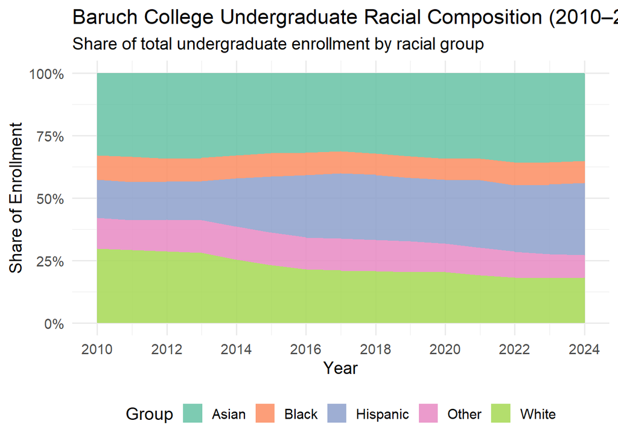

Figure 1: Baruch College undergraduate racial composition, 2010–2024

```r
IPEDS_total |>
    filter(str_detect(institution_name, "Baruch"),
           level == "all undergrad") |>
    mutate(
        Asian    = (enrollment_m_asia + enrollment_f_asia) / total_enrollment,
        Black    = (enrollment_m_bkaa + enrollment_f_bkaa) / total_enrollment,
        Hispanic = (enrollment_m_hisp + enrollment_f_hisp) / total_enrollment,
        White    = (enrollment_m_whit + enrollment_f_whit) / total_enrollment,
        Other    = 1 - Asian - Black - Hispanic - White
    ) |>
    select(year, Asian, Black, Hispanic, White, Other) |>
    pivot_longer(-year, names_to = "race", values_to = "proportion") |>
    ggplot(aes(x = year, y = proportion, fill = race)) +
    geom_area(alpha = 0.85) +
    scale_y_continuous(labels = scales::percent_format(accuracy = 1)) +
    scale_x_continuous(breaks = seq(2010, 2024, 2)) +
    scale_fill_brewer(palette = "Set2") +
    labs(title    = "Baruch College Undergraduate Racial Composition (2010–2024)",
         subtitle = "Share of total undergraduate enrollment by racial group",
         x = "Year", y = "Share of Enrollment", fill = "Group") +
    theme_minimal(base_size = 14) +
    theme(legend.position = "bottom")
```

**CUNY First-Year Enrollment Share 2024**

**View R Code**

```r
total_fy_2024 <- IPEDS_total |>
    filter(year == 2024, level == "first year undergrad") |>
    summarize(total = sum(total_enrollment, na.rm = TRUE)) |>
    pull(total)

IPEDS_total |>
    filter(year == 2024, level == "first year undergrad", is_cuny) |>
    mutate(
        institution_name = str_remove(institution_name, "CUNY "),
        pct_of_us        = total_enrollment / total_fy_2024
    ) |>
    select(institution_name, total_enrollment, pct_of_us) |>
    arrange(desc(total_enrollment)) |>
    gt() |>
    tab_header(
        title    = "CUNY First-Year Enrollment Share (2024)",
        subtitle = "Each campus as a share of all U.S. first-year undergraduates"
    ) |>
    cols_label(
        institution_name = "Campus",
        total_enrollment = "First-Year Students",
        pct_of_us        = "Share of U.S. Total"
    ) |>
    fmt_number(columns = total_enrollment, decimals = 0) |>
    fmt_percent(columns = pct_of_us, decimals = 3) |>
    tab_source_note("Source: IPEDS 2024 via NCES. 'CUNY' prefix removed from campus names for readability.") |>
    style_gt()
```

CUNY First-Year Enrollment Share (2024)

Each campus as a share of all U.S. first-year undergraduates

| Campus | First-Year Students | Share of U.S. Total |
| --- | --- | --- |
| Borough of Manhattan Community College | 4,718 | 0.152% |
| New York City College of Technology | 3,585 | 0.115% |
| Hunter College | 2,897 | 0.093% |
| City College | 2,543 | 0.082% |
| Bernard M Baruch College | 2,532 | 0.081% |
| LaGuardia Community College | 2,406 | 0.077% |
| College of Staten Island CUNY | 2,196 | 0.071% |
| John Jay College of Criminal Justice | 2,128 | 0.068% |
| Queensborough Community College | 1,965 | 0.063% |
| Brooklyn College | 1,782 | 0.057% |
| Queens College | 1,751 | 0.056% |
| Kingsborough Community College | 1,615 | 0.052% |
| Lehman College | 1,545 | 0.050% |
| Bronx Community College | 1,252 | 0.040% |
| Hostos Community College | 844 | 0.027% |
| York College | 766 | 0.025% |
| Medgar Evers College | 586 | 0.019% |
| Stella and Charles Guttman Community College | 367 | 0.012% |
| Graduate School and University Center | 12 | 0.000% |

Source: IPEDS 2024 via NCES. 'CUNY' prefix removed from campus names for readability.

**CUNY Enrollment by Campus**

**View R Code**

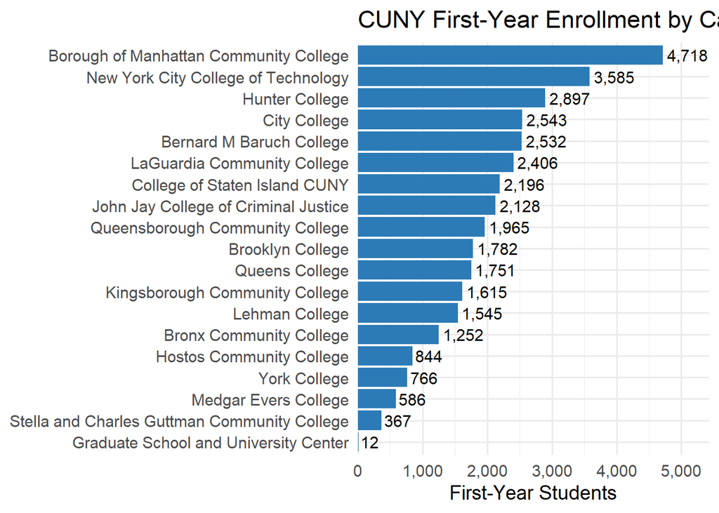

Figure 2: CUNY first-year enrollment by campus, 2024

```r
IPEDS_total |>
    filter(year == 2024, level == "first year undergrad", is_cuny) |>
    mutate(institution_name = str_remove(institution_name, "CUNY ")) |>
    arrange(total_enrollment) |>
    mutate(institution_name = fct_inorder(institution_name)) |>
    ggplot(aes(x = total_enrollment, y = institution_name)) +
    geom_col(fill = "#2c7bb6") +
    geom_text(aes(label = scales::comma(total_enrollment)),
              hjust = -0.1, size = 4) +
    scale_x_continuous(labels = scales::comma,
                       expand = expansion(mult = c(0, 0.15))) +
    labs(title = "CUNY First-Year Enrollment by Campus (2024)",
         x = "First-Year Students", y = NULL) +
    theme_minimal(base_size = 14)
```

**Diversity Decreases**

**View R Code**

```r
IPEDS_total |>
    filter(year %in% c(2010, 2020), level == "all undergrad") |>
    filter(total_enrollment > 1000) |>
    mutate(white_prop = (enrollment_m_whit + enrollment_f_whit) / total_enrollment) |>
    select(institution_id, institution_name, year, white_prop) |>
    pivot_wider(
        id_cols    = c(institution_id, institution_name),
        names_from = year,
        values_from = white_prop
    ) |>
    rename(white_prop_2010 = `2010`, white_prop_2020 = `2020`) |>
    filter(!is.na(white_prop_2010) & !is.na(white_prop_2020)) |>
    mutate(diff = white_prop_2020 - white_prop_2010) |>
    arrange(diff) |>
    slice(1:5) |>
    select(institution_name, white_prop_2010, white_prop_2020, diff) |>
    gt() |>
    tab_header(
        title    = "Largest Decrease in White Student Fraction (2010–2020)",
        subtitle = "Limited to institutions with more than 1,000 undergraduates"
    ) |>
    cols_label(
        institution_name = "Institution",
        white_prop_2010  = "2010",
        white_prop_2020  = "2020",
        diff             = "Change"
    ) |>
    fmt_percent(columns = c(white_prop_2010, white_prop_2020, diff), decimals = 2) |>
    tab_source_note("Source: IPEDS 2010 & 2020 via NCES. Change = 2020 minus 2010 white student share.") |>
    style_gt()
```

Largest Decrease in White Student Fraction (2010–2020)

Limited to institutions with more than 1,000 undergraduates

| Institution | 2010 | 2020 | Change |
| --- | --- | --- | --- |
| University of the Cumberlands | 82.25% | 12.41% | −69.83% |
| Southeastern Community College | 85.56% | 22.04% | −63.52% |
| New England Institute of Technology | 66.97% | 7.92% | −59.05% |
| Saint Joseph's College of Maine | 70.73% | 19.71% | −51.02% |
| Montcalm Community College | 89.47% | 46.46% | −43.00% |

Source: IPEDS 2010 & 2020 via NCES. Change = 2020 minus 2010 white student share.

**Female Undergrad Growth by State**

**View R Code**

```r
IPEDS_total |>
    filter(year %in% c(2010, 2024), level == "all undergrad") |>
    mutate(female_prop = rowSums(across(contains("_f_")),
                                 na.rm = TRUE) / total_enrollment) |>
    select(state, year, female_prop) |>
    group_by(state, year) |>
    summarize(female_prop = mean(female_prop, na.rm = TRUE),
              .groups = "drop") |>
    pivot_wider(names_from = year, values_from = female_prop) |>
    rename(prop_2010 = `2010`, prop_2024 = `2024`) |>
    filter(!is.na(prop_2010) & !is.na(prop_2024)) |>
    mutate(diff = prop_2024 - prop_2010) |>
    arrange(desc(diff)) |>
    slice(1:3) |>
    gt() |>
    tab_header(
        title    = "States with Largest Increase in Female Undergraduates",
        subtitle = "Change in female share of undergraduate enrollment, 2010–2024"
    ) |>
    cols_label(
        state     = "State",
        prop_2010 = "2010",
        prop_2024 = "2024",
        diff      = "Change"
    ) |>
    fmt_percent(columns = c(prop_2010, prop_2024, diff), decimals = 2) |>
    tab_source_note("Source: IPEDS 2010 & 2024 via NCES.") |>
    style_gt()
```

States with Largest Increase in Female Undergraduates

Change in female share of undergraduate enrollment, 2010–2024

| State | 2010 | 2024 | Change |
| --- | --- | --- | --- |
| FM | 53.72% | 62.87% | 9.15% |
| AS | 61.19% | 70.23% | 9.03% |
| UT | 69.10% | 74.41% | 5.31% |

Source: IPEDS 2010 & 2024 via NCES.

## 5 Final Insights and Deliverable

The chart below tracks Baruch’s minority diversity index from 2010 through the first post-SFFA admissions cycle.

**View R Code**

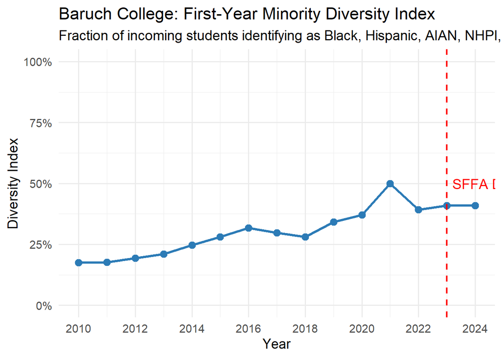

Figure 3: Baruch College first-year minority diversity index, 2010–2024

```r
diversity_data |>
    filter(str_detect(institution_name, "Baruch"),
           level == "first year undergrad") |>
    ggplot(aes(x = year, y = diversity_idx)) +
    geom_line(linewidth = 1.2, color = "#2c7bb6") +
    geom_point(size = 3, color = "#2c7bb6") +
    geom_vline(xintercept = 2023, linetype = "dashed",
               color = "red", linewidth = 0.8) +
    annotate("text", x = 2023.2, y = 0.5,
             label = "SFFA Decision", hjust = 0, color = "red") +
    scale_y_continuous(labels = scales::percent_format(accuracy = 1),
                       limits = c(0, 1)) +
    scale_x_continuous(breaks = seq(2010, 2024, 2)) +
    labs(title    = "Baruch College: First-Year Minority Diversity Index",
         subtitle = "Fraction of incoming students identifying as Black, Hispanic, AIAN, NHPI, or Multiracial",
         x = "Year", y = "Diversity Index") +
    theme_minimal(base_size = 14)
```

**View R Code**

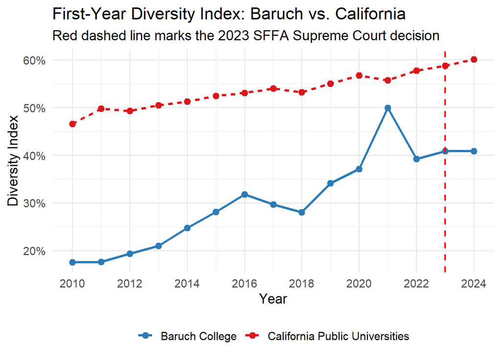

Figure 4: Diversity index comparison: Baruch vs. California public universities

```r
baruch_trend <- diversity_data |>
    filter(str_detect(institution_name, "Baruch"),
           level == "first year undergrad") |>
    group_by(year) |>
    summarize(diversity_idx = mean(diversity_idx, na.rm = TRUE)) |>
    mutate(system = "Baruch College")

cal_trend <- diversity_data |>
    filter(is_calpublic, level == "first year undergrad") |>
    group_by(year) |>
    summarize(diversity_idx = mean(diversity_idx, na.rm = TRUE)) |>
    mutate(system = "California Public Universities")

bind_rows(baruch_trend, cal_trend) |>
    ggplot(aes(x = year, y = diversity_idx,
               color = system, linetype = system)) +
    geom_line(linewidth = 1.2) +
    geom_point(size = 2.5) +
    geom_vline(xintercept = 2023, linetype = "dashed",
               color = "red", linewidth = 0.8) +
    scale_y_continuous(labels = scales::percent_format(accuracy = 1)) +
    scale_x_continuous(breaks = seq(2010, 2024, 2)) +
    scale_color_manual(values = c("Baruch College" = "#2c7bb6",
                                  "California Public Universities" = "#d7191c")) +
    labs(title    = "First-Year Diversity Index: Baruch vs. California",
         subtitle = "Red dashed line marks the 2023 SFFA Supreme Court decision",
         x = "Year", y = "Diversity Index",
         color = NULL, linetype = NULL) +
    theme_minimal(base_size = 14) +
    theme(legend.position = "bottom")
```

**Tip✍️ Diversity as a Demographic Destiny: A Baruch Perspective**

*By President Raúl J. Solá Navarro*

At Baruch College, we define diversity as the proportion of students who self-identify as Black, Hispanic, American Indian or Alaskan Native, Native Hawaiian or Pacific Islander, or Multiracial. These are groups historically underrepresented at higher education institutions in the United States. The definition, consistent with IPEDS reporting categories, intentionally excludes White and Asian-American students, reflecting the social context in which affirmative action policies were originally founded on.

The 2023 Students for Fair Admissions (SFFA) Supreme Court decision has forced institutions in the United States to reconsider how they define a fair admission’s process. At Baruch, we don’t think of diversity as a quota, but as a demographic reality that reflects the composition of the City.

Shifting our focus to California, public universities there have operated under race-neutral admissions mandates since Proposition 209 in 1996. This means that the SFFA decision should have had no practical effect on their policies. In 2023, the California public system’s average first-year diversity index stood at 58.8% and shifted to 60.1% in 2024; this reflects a change of just 1.3%. The fact that Baruch’s year-over-year movement is comparably small to Baruch’s, suggests that what we are observing may reflect normal demographic variation rather than a structural post-SFFA shift.

The stability in California, and the resilience at Baruch, suggests that institutional mission and local demographics may be stronger forces than even the Supreme Court’s majority opinion. Our challenge moving forward is to remain true to what our institution stands for by doubling down on the pipeline programs, transfer pathways, and community partnerships that ensure every New Yorker sees a seat for themselves at our table.

**NoteGenerative AI Disclosure**

In completing this mini-project, I used Claude (Anthropic) and Gemini (Google) to assist with debugging R code errors, specifically regarding pivot_wider list-column issues, gt table styling, and Quarto rendering. All analytical framing, written text, and interpretations are my own.

This work ©2026 by Raúl J. Solá Navarro was prepared as a Mini-Project for  
[STA 9750](https://michael-weylandt.com/STA9750) at Baruch College · [MP #01 Instructions](https://michael-weylandt.com/STA9750/mini/mini01.html)